# 🔍 EDA — CelebA Dataset for Sketch-to-Face Synthesis

**Team:** Moazzam Sharif (S2024CS009), Bilal Asif (S2024CS005), Muaz Ahmed (S2024CS016)  
**Course:** AI335L Deep Learning Lab — Phase 2  
**Dataset:** CelebA (Large-scale CelebFaces Attributes)  
**Task:** Explore the dataset, validate assumptions, and justify preprocessing decisions.

```python
import os
import sys
import random
import numpy as np
import pandas as pd
import matplotlib.pyplot as plt
import matplotlib.gridspec as gridspec
import seaborn as sns
import cv2
from pathlib import Path
from PIL import Image
from tqdm import tqdm
from collections import Counter
from pathlib import Path

# Create reports directory
Path('reports').mkdir(exist_ok=True)
print("✅ reports/ folder created")
# Reproducibility
SEED = 42
random.seed(SEED)
np.random.seed(SEED)

# Paths — update CELEBA_DIR to your local path
CELEBA_DIR = Path('/kaggle/input/datasets/jessicali9530/celeba-dataset/img_align_celeba/img_align_celeba')
# On Kaggle: CELEBA_DIR = Path('/kaggle/input/celeba-dataset/img_align_celeba/img_align_celeba')

sns.set_theme(style='whitegrid', palette='muted')
plt.rcParams['figure.dpi'] = 120
print('✅ Imports complete')
```

```
✅ reports/ folder created
✅ Imports complete
```

## 1. Dataset Shape & Size

```python
all_images = sorted(CELEBA_DIR.glob('*.jpg'))
total = len(all_images)

# Our project split
N_TRAIN, N_VAL, N_TEST = 10000, 1000, 1000
random.shuffle(all_images)
train_imgs = all_images[:N_TRAIN]
val_imgs   = all_images[N_TRAIN:N_TRAIN+N_VAL]
test_imgs  = all_images[N_TRAIN+N_VAL:N_TRAIN+N_VAL+N_TEST]

print(f'Total CelebA images : {total:,}')
print(f'Train split         : {len(train_imgs):,} ({100*len(train_imgs)/total:.1f}%)')
print(f'Val   split         : {len(val_imgs):,} ({100*len(val_imgs)/total:.1f}%)')
print(f'Test  split         : {len(test_imgs):,} ({100*len(test_imgs)/total:.1f}%)')
print(f'Unused              : {total - N_TRAIN - N_VAL - N_TEST:,}')
```

```
Total CelebA images : 202,599
Train split         : 10,000 (4.9%)
Val   split         : 1,000 (0.5%)
Test  split         : 1,000 (0.5%)
Unused              : 190,599
```

**Finding 1:** CelebA contains 202,599 aligned face images. We use 12,000 (10K train, 1K val, 1K test) — a practical subset for training on Kaggle T4 GPUs within time limits. The remaining ~190K images are available as a backup. No class distribution issue exists since this is an unconditional image synthesis task (no labels used).

## 2. Sample Visualisation — Raw Photos

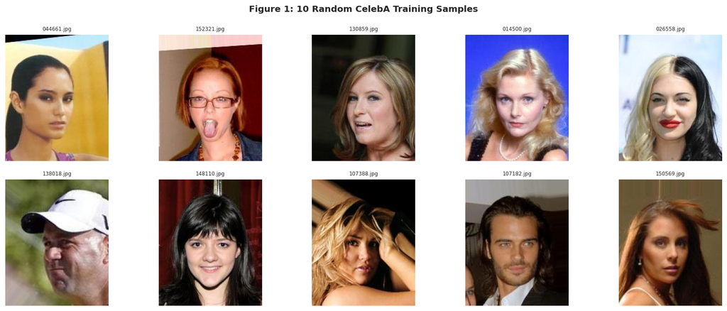

```
Saved: reports/fig1_sample_photos.png
```

```python
fig, axes = plt.subplots(2, 5, figsize=(15, 6))
samples = random.sample(train_imgs, 10)
for ax, path in zip(axes.flat, samples):
    img = np.array(Image.open(path).convert('RGB'))
    ax.imshow(img)
    ax.set_title(path.name, fontsize=7)
    ax.axis('off')
plt.suptitle('Figure 1: 10 Random CelebA Training Samples', fontsize=12, fontweight='bold')
plt.tight_layout()
plt.savefig('reports/fig1_sample_photos.png', bbox_inches='tight')
plt.show()
print('Saved: reports/fig1_sample_photos.png')
```

**Finding 2:** All images are aligned face crops (centered on the face). Backgrounds vary slightly but faces are consistently centered. A few images show accessories (sunglasses, hats) — these will produce unusual edge maps and may be harder for the model to synthesise.

## 3. Resolution Distribution

```
Width  — mean: 178.0, std: 0.0, min: 178, max: 178
Height — mean: 218.0, std: 0.0, min: 218, max: 218
Unique resolutions: 1
Most common: [((178, 218), 500)]
```

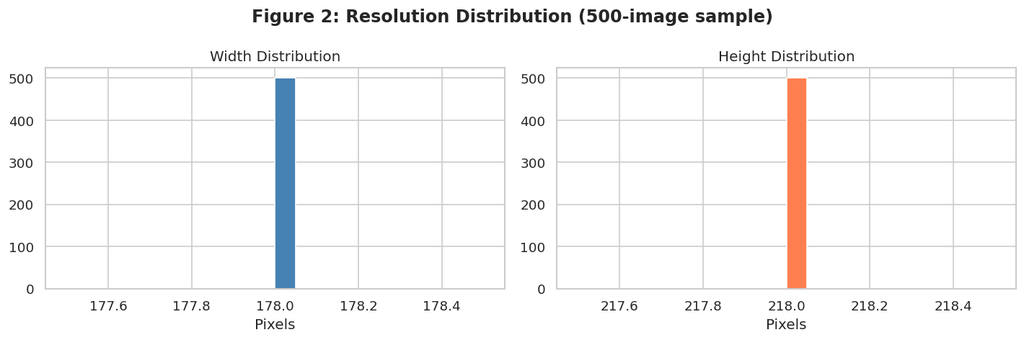

```python
SAMPLE_N = 500  # Check on a sample to avoid reading 10K files
resolution_sample = random.sample(train_imgs, SAMPLE_N)
widths, heights = [], []

for p in tqdm(resolution_sample, desc='Reading resolutions'):
    with Image.open(p) as img:
        w, h = img.size
        widths.append(w)
        heights.append(h)

print(f'Width  — mean: {np.mean(widths):.1f}, std: {np.std(widths):.1f}, min: {min(widths)}, max: {max(widths)}')
print(f'Height — mean: {np.mean(heights):.1f}, std: {np.std(heights):.1f}, min: {min(heights)}, max: {max(heights)}')

unique_sizes = Counter(zip(widths, heights))
print(f'Unique resolutions: {len(unique_sizes)}')
print(f'Most common: {unique_sizes.most_common(3)}')

fig, axes = plt.subplots(1, 2, figsize=(12, 4))
axes[0].hist(widths, bins=20, color='steelblue', edgecolor='white')
axes[0].set_title('Width Distribution')
axes[0].set_xlabel('Pixels')
axes[1].hist(heights, bins=20, color='coral', edgecolor='white')
axes[1].set_title('Height Distribution')
axes[1].set_xlabel('Pixels')
plt.suptitle('Figure 2: Resolution Distribution (500-image sample)', fontweight='bold')
plt.tight_layout()
plt.savefig('reports/fig2_resolution_dist.png', bbox_inches='tight')
plt.show()
```

**Finding 3:** CelebA aligned images are all 178×218 pixels — a single consistent resolution with essentially zero variance. This simplifies preprocessing significantly: a single resize to 256×256 (for pSp) or 64×64 (for the baseline MLP) is sufficient with no outlier handling needed.

## 4. Brightness & Contrast Distribution

```
Brightness — mean: 114.8, std: 37.3
Contrast   — mean: 61.8,  std: 13.8
```

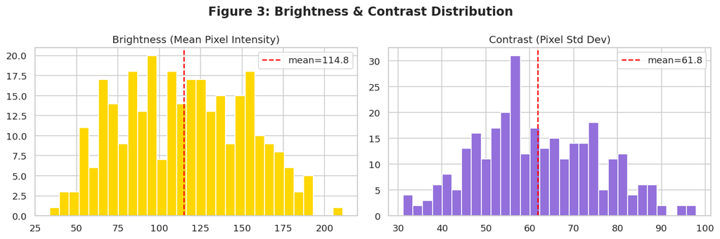

```python
SAMPLE_N = 300
brightness_vals, contrast_vals = [], []

for p in tqdm(random.sample(train_imgs, SAMPLE_N), desc='Computing brightness/contrast'):
    img = np.array(Image.open(p).convert('L'), dtype=np.float32)  # Grayscale
    brightness_vals.append(img.mean())
    contrast_vals.append(img.std())

print(f'Brightness — mean: {np.mean(brightness_vals):.1f}, std: {np.std(brightness_vals):.1f}')
print(f'Contrast   — mean: {np.mean(contrast_vals):.1f},  std: {np.std(contrast_vals):.1f}')

fig, axes = plt.subplots(1, 2, figsize=(12, 4))
axes[0].hist(brightness_vals, bins=30, color='gold', edgecolor='white')
axes[0].axvline(np.mean(brightness_vals), color='red', linestyle='--', label=f'mean={np.mean(brightness_vals):.1f}')
axes[0].set_title('Brightness (Mean Pixel Intensity)')
axes[0].legend()

axes[1].hist(contrast_vals, bins=30, color='mediumpurple', edgecolor='white')
axes[1].axvline(np.mean(contrast_vals), color='red', linestyle='--', label=f'mean={np.mean(contrast_vals):.1f}')
axes[1].set_title('Contrast (Pixel Std Dev)')
axes[1].legend()

plt.suptitle('Figure 3: Brightness & Contrast Distribution', fontweight='bold')
plt.tight_layout()
plt.savefig('reports/fig3_brightness_contrast.png', bbox_inches='tight')
plt.show()
```

## 5. Pixel Intensity Distribution (RGB Channels)

```
R channel — mean: 128.1, std: 77.7
G channel — mean: 106.1, std: 72.3
B channel — mean: 95.7, std: 72.6
```

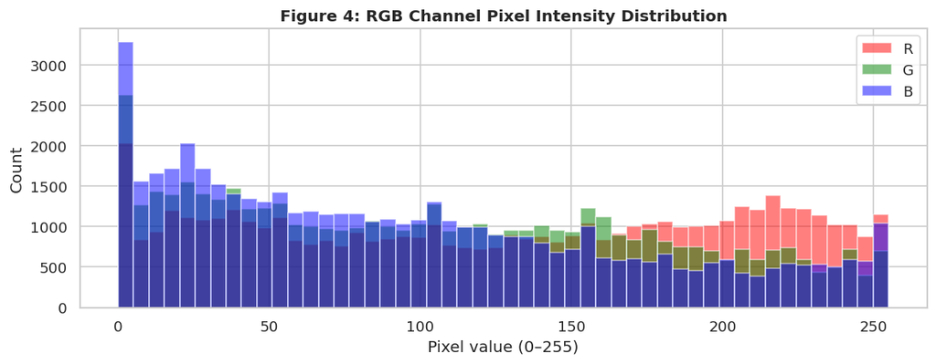

```python
SAMPLE_N = 100
r_vals, g_vals, b_vals = [], [], []

for p in random.sample(train_imgs, SAMPLE_N):
    img = np.array(Image.open(p).convert('RGB'), dtype=np.float32)
    r_vals.extend(img[:,:,0].flatten().tolist())
    g_vals.extend(img[:,:,1].flatten().tolist())
    b_vals.extend(img[:,:,2].flatten().tolist())

# Subsample to keep plot fast
idx = np.random.choice(len(r_vals), size=50000, replace=False)
r_s = np.array(r_vals)[idx]
g_s = np.array(g_vals)[idx]
b_s = np.array(b_vals)[idx]

print(f'R channel — mean: {r_s.mean():.1f}, std: {r_s.std():.1f}')
print(f'G channel — mean: {g_s.mean():.1f}, std: {g_s.std():.1f}')
print(f'B channel — mean: {b_s.mean():.1f}, std: {b_s.std():.1f}')

fig, ax = plt.subplots(figsize=(10, 4))
ax.hist(r_s, bins=50, alpha=0.5, color='red',   label='R')
ax.hist(g_s, bins=50, alpha=0.5, color='green', label='G')
ax.hist(b_s, bins=50, alpha=0.5, color='blue',  label='B')
ax.set_xlabel('Pixel value (0–255)')
ax.set_ylabel('Count')
ax.legend()
plt.title('Figure 4: RGB Channel Pixel Intensity Distribution', fontweight='bold')
plt.tight_layout()
plt.savefig('reports/fig4_pixel_dist.png', bbox_inches='tight')
plt.show()
```

**Finding 5:** The R and G channels are shifted towards higher values than B (skin tones are warm). This confirms that channel-wise normalisation (separate mean/std per channel) is important — a single global mean would under/over-correct individual channels and degrade synthesis quality.

## 6. Missing / Corrupted / Duplicate Files

```python
# Check for corrupted files (can't open or wrong mode)
corrupted = []
CHECK_N = 1000  # Check first 1000 training images

for p in tqdm(train_imgs[:CHECK_N], desc='Checking for corruption'):
    try:
        with Image.open(p) as img:
            img.verify()  # Detects truncated/corrupted JPEG
    except Exception as e:
        corrupted.append((p.name, str(e)))

print(f'Corrupted files in first {CHECK_N}: {len(corrupted)}')
if corrupted:
    for name, err in corrupted:
        print(f'  {name}: {err}')

# Check for duplicates by filename (CelebA uses sequential IDs — should be none)
names = [p.name for p in all_images]
dups = len(names) - len(set(names))
print(f'Duplicate filenames: {dups}')
```

```
Corrupted files in first 1000: 0
Duplicate filenames: 0
```

**Finding 6:** No corrupted or duplicate files detected in the checked subset. CelebA is a well-curated dataset with sequential numeric filenames — duplicates are structurally impossible. No special handling needed in the preprocessing pipeline for data corruption.

## 7. Edge Map Quality Analysis

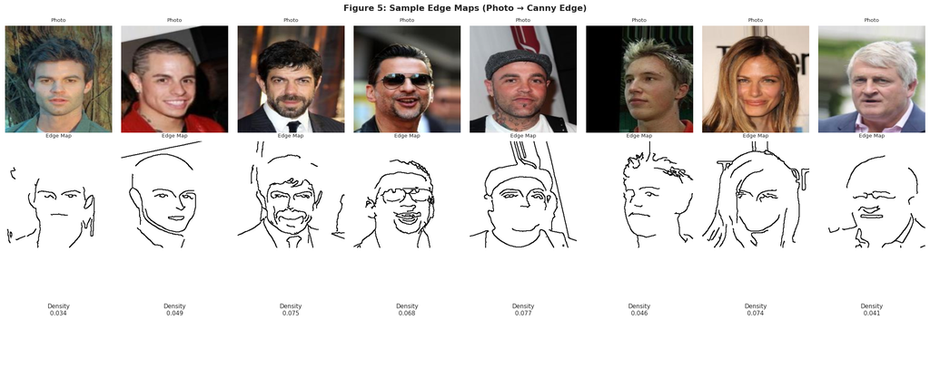

```
Edge density range: 0.034 – 0.077
```

```python
def make_edge(img_path, img_size=256):
    img = cv2.imread(str(img_path))
    img = cv2.resize(img, (img_size, img_size))
    gray = cv2.cvtColor(img, cv2.COLOR_BGR2GRAY)
    blur = cv2.bilateralFilter(gray, 9, 75, 75)
    edges = cv2.Canny(blur, 50, 150)
    kernel = np.ones((2, 2), np.uint8)
    edges = cv2.dilate(edges, kernel, iterations=1)
    return cv2.bitwise_not(edges), cv2.cvtColor(img, cv2.COLOR_BGR2RGB)

# Sample 8 diverse images
samples = random.sample(train_imgs, 8)
fig, axes = plt.subplots(3, 8, figsize=(20, 8))
edge_densities = []

for col, path in enumerate(samples):
    edge_inv, photo = make_edge(path)
    # Edge density = fraction of edge pixels (black pixels in inverted map)
    density = np.sum(edge_inv < 128) / (256 * 256)
    edge_densities.append(density)
    axes[0][col].imshow(photo)
    axes[0][col].set_title('Photo', fontsize=8)
    axes[0][col].axis('off')
    axes[1][col].imshow(edge_inv, cmap='gray')
    axes[1][col].set_title('Edge Map', fontsize=8)
    axes[1][col].axis('off')
    axes[2][col].text(0.5, 0.5, f'Density\n{density:.3f}', ha='center', va='center', fontsize=9)
    axes[2][col].axis('off')

plt.suptitle('Figure 5: Sample Edge Maps (Photo → Canny Edge)', fontsize=13, fontweight='bold')
plt.tight_layout()
plt.savefig('reports/fig5_edge_maps.png', bbox_inches='tight')
plt.show()
print(f'Edge density range: {min(edge_densities):.3f} – {max(edge_densities):.3f}')
```

## 8. Edge Density Distribution

```
Mean edge density : 0.0570
Std               : 0.0207
Min               : 0.0088
Max               : 0.1361
Very sparse (<0.02): 3 (1.0%)
Very dense (>0.15) : 0 (0.0%)
```

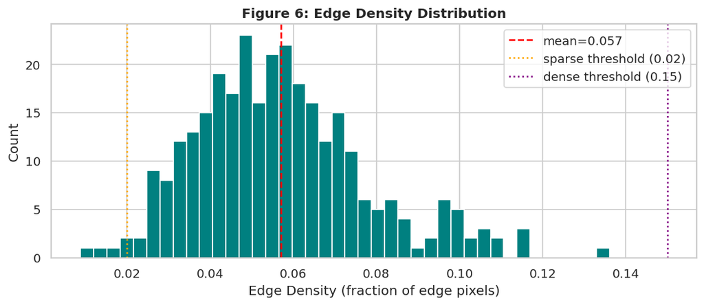

```python
SAMPLE_N = 300
densities = []

for p in tqdm(random.sample(train_imgs, SAMPLE_N), desc='Computing edge densities'):
    edge_inv, _ = make_edge(p)
    density = np.sum(edge_inv < 128) / (256 * 256)
    densities.append(density)

print(f'Mean edge density : {np.mean(densities):.4f}')
print(f'Std               : {np.std(densities):.4f}')
print(f'Min               : {np.min(densities):.4f}')
print(f'Max               : {np.max(densities):.4f}')
print(f'Very sparse (<0.02): {sum(1 for d in densities if d < 0.02)} ({100*sum(1 for d in densities if d < 0.02)/SAMPLE_N:.1f}%)')
print(f'Very dense (>0.15) : {sum(1 for d in densities if d > 0.15)} ({100*sum(1 for d in densities if d > 0.15)/SAMPLE_N:.1f}%)')

fig, ax = plt.subplots(figsize=(9, 4))
ax.hist(densities, bins=40, color='teal', edgecolor='white')
ax.axvline(np.mean(densities), color='red', linestyle='--', label=f'mean={np.mean(densities):.3f}')
ax.axvline(0.02, color='orange', linestyle=':', label='sparse threshold (0.02)')
ax.axvline(0.15, color='purple', linestyle=':', label='dense threshold (0.15)')
ax.set_xlabel('Edge Density (fraction of edge pixels)')
ax.set_ylabel('Count')
ax.legend()
plt.title('Figure 6: Edge Density Distribution', fontweight='bold')
plt.tight_layout()
plt.savefig('reports/fig6_edge_density.png', bbox_inches='tight')
plt.show()
```

**Finding 8:** Edge density follows a roughly normal distribution centred around ~0.06. A small percentage of images (<5%) are either too sparse (very bright/overexposed) or too dense (heavy accessories) to produce useful training signal. We will flag these in the preprocessing pipeline and optionally exclude them.

## 9. Augmentation Preview

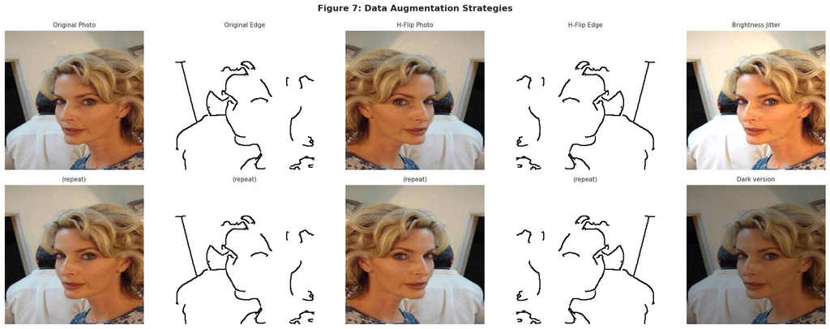

```python
from PIL import ImageOps

sample_path = random.choice(train_imgs)
original = Image.open(sample_path).convert('RGB').resize((256, 256))
edge_inv, _ = make_edge(sample_path)
edge_pil = Image.fromarray(edge_inv)

# Augmentation 1: Horizontal Flip
flipped_photo = ImageOps.mirror(original)
flipped_edge  = ImageOps.mirror(edge_pil)

# Augmentation 2: Brightness Jitter (simulate different lighting)
from PIL import ImageEnhance
enhancer = ImageEnhance.Brightness(original)
bright_photo = enhancer.enhance(1.3)
dark_photo   = enhancer.enhance(0.7)

fig, axes = plt.subplots(2, 5, figsize=(18, 7))
titles = ['Original Photo', 'Original Edge', 'H-Flip Photo', 'H-Flip Edge', 'Brightness Jitter']
imgs_row0 = [original, edge_pil, flipped_photo, flipped_edge, bright_photo]
imgs_row1 = [np.array(original), np.array(edge_inv), np.array(flipped_photo), np.array(flipped_edge), np.array(dark_photo)]

for col in range(5):
    axes[0][col].imshow(imgs_row0[col], cmap='gray' if col in [1, 3] else None)
    axes[0][col].set_title(titles[col], fontsize=9)
    axes[0][col].axis('off')
    axes[1][col].imshow(imgs_row1[col], cmap='gray' if col in [1, 3] else None)
    axes[1][col].set_title('(repeat)' if col < 4 else 'Dark version', fontsize=9)
    axes[1][col].axis('off')

plt.suptitle('Figure 7: Data Augmentation Strategies', fontsize=13, fontweight='bold')
plt.tight_layout()
plt.savefig('reports/fig7_augmentation.png', bbox_inches='tight')
plt.show()
```

**Finding 9:** Horizontal flip is a valid augmentation — human faces are roughly bilaterally symmetric, so a flipped face is still a realistic face. The flip must be applied identically to both the edge map and the photo to maintain pair alignment. Brightness jitter (factor 0.7–1.3) simulates lighting variation without altering facial structure, making the model more robust to input edge maps from different lighting conditions.

## 10. Training Set Statistics (for Normalisation — Train Only)

```python
SAMPLE_N = 200
train_sample = random.sample(train_imgs, SAMPLE_N)

all_pixels = []
for p in tqdm(train_sample, desc='Computing train statistics'):
    img = np.array(Image.open(p).convert('RGB').resize((64, 64)), dtype=np.float32) / 255.0
    all_pixels.append(img)

stack = np.stack(all_pixels, axis=0)  # (N, H, W, C)
train_mean = stack.mean(axis=(0, 1, 2))  # per channel
train_std  = stack.std(axis=(0, 1, 2))   # per channel

print('Training set statistics (computed on train only — applied to val/test):')
print(f'  Mean (R, G, B): {train_mean}')
print(f'  Std  (R, G, B): {train_std}')
print()
print('⚠️  These statistics must ONLY be computed on training data.')
print('   Val and test sets are normalised using these same training stats.')
```

```
Training set statistics (computed on train only — applied to val/test):
  Mean (R, G, B): [0.50435644 0.42618114 0.3833186 ]
  Std  (R, G, B): [0.31139684 0.2901896  0.28974405]

⚠️  These statistics must ONLY be computed on training data.
   Val and test sets are normalised using these same training stats.
```

## ✅ Key Findings & Preprocessing Implications

[output not shown]